# Project Problem Statement - FMST

### Observations:

- Target attribute strength do not show any kind of relationship with other independent attributes except cement and superplastic. Attributes cement and superplastic seem to have linear relationship with target attribute.
- Attribute water seems to be negatively related with strength
- Attribute age do not show any relation with other independent attributes. Slightly non-linear relation can be observed between age and strength
- fineagg and coarseagg shows slight negative linear relationship with water
- superplastic attribute has negative correlation with the water.
- Except for strength and cement attributes, density curves for most of the attribute show multiple peaks

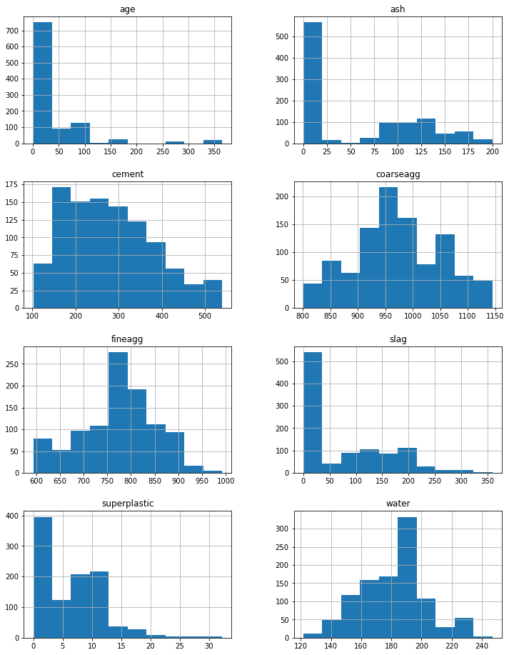

```python
# Let's us only plot the distributions of independent attributes
df.drop('strength',axis=1).hist(figsize=(12,16),layout=(4,2));
```

```python
# Let's check the skewness values quantitatively
df.skew().sort_values(ascending=False)
```

```
age             3.269177
superplastic    0.907203
slag            0.800717
ash             0.537354
cement          0.509481
strength        0.416977
water           0.074628
coarseagg      -0.040220
fineagg        -0.253010
dtype: float64
```

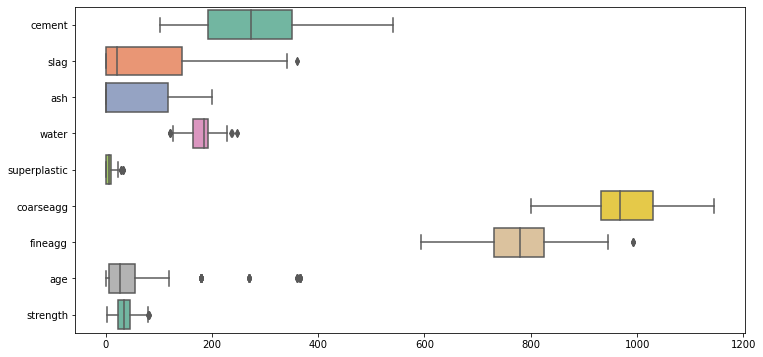

```python
plt.figure(figsize=(12,6))
sns.boxplot(data=df, orient="h", palette="Set2", dodge=False)
```

- These are the columns which have most outliers : **water**, **superplastic** and **age**

Pick one strategy to address the presence outliers and missing values and perform necessary imputation Since there are no missing values in the dataset, no missing value imputation is necessary.

#### Fixing Outliers

```python
# remove the outliers
for column in df.columns.tolist():
    Q1 = df[column].quantile(.25) # 1st quartile
    Q3 = df[column].quantile(.75) # 3rd quartile
    IQR = Q3-Q1 # get inter quartile range
    # Replace elements of columns that fall below Q1-1.5*IQR and above Q3+1.5*IQR
    df[column].replace(df.loc[(df[column] > Q3+1.5*IQR)|(df[column] < Q1-1.5*IQR), column], df[column].median(),inplace=True)
```

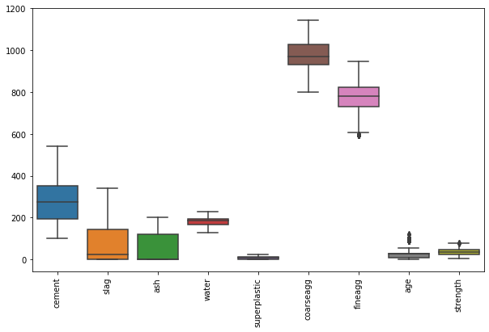

```python
# check presence of outliers after removal
plt.figure(figsize=(10,6))
box = sns.boxplot(data=df)
box.set_xticklabels(labels=box.get_xticklabels(),rotation=90);
```

#### Observations after outlier removal:

- Outliers are completely removed from slag, water, superplastic attributes
- New outliers below first quartile are created in fineagg column. However, we are not going to treat them again.
- Age attribute still shows some outliers
- Outliers in the strength column are not removed completely.

### 5. Feature Engineering techniques

In this problem, we do have an opportunity to add a composite feature which is highly useful to predict the concrete strength in MPa namely water-cement ratio.

```python
# add new feature composit of water and cement and get the ratio for it
df['water/cement']= df['water']/df['cement']
df
```

|  | cement | slag | ash | water | superplastic | coarseagg | fineagg | age | strength | water/cement |
| --- | --- | --- | --- | --- | --- | --- | --- | --- | --- | --- |
| 0 | 141.3 | 212.0 | 0.0 | 203.5 | 0.0 | 971.8 | 748.5 | 28 | 29.89 | 1.440198 |
| 1 | 168.9 | 42.2 | 124.3 | 158.3 | 10.8 | 1080.8 | 796.2 | 14 | 23.51 | 0.937241 |
| 2 | 250.0 | 0.0 | 95.7 | 187.4 | 5.5 | 956.9 | 861.2 | 28 | 29.22 | 0.749600 |
| 3 | 266.0 | 114.0 | 0.0 | 228.0 | 0.0 | 932.0 | 670.0 | 28 | 45.85 | 0.857143 |
| 4 | 154.8 | 183.4 | 0.0 | 193.3 | 9.1 | 1047.4 | 696.7 | 28 | 18.29 | 1.248708 |
| ... | ... | ... | ... | ... | ... | ... | ... | ... | ... | ... |
| 1025 | 135.0 | 0.0 | 166.0 | 180.0 | 10.0 | 961.0 | 805.0 | 28 | 13.29 | 1.333333 |
| 1026 | 531.3 | 0.0 | 0.0 | 141.8 | 6.4 | 852.1 | 893.7 | 3 | 41.30 | 0.266893 |
| 1027 | 276.4 | 116.0 | 90.3 | 179.6 | 8.9 | 870.1 | 768.3 | 28 | 44.28 | 0.649783 |
| 1028 | 342.0 | 38.0 | 0.0 | 228.0 | 0.0 | 932.0 | 670.0 | 28 | 55.06 | 0.666667 |
| 1029 | 540.0 | 0.0 | 0.0 | 173.0 | 0.0 | 1125.0 | 613.0 | 7 | 52.61 | 0.320370 |

1030 rows × 10 columns

### Check for the relationship between new feature (water/cement) with target ( strength) and other attributes

```python
df.corr()
```

|  | cement | slag | ash | water | superplastic | coarseagg | fineagg | age | strength | water/cement |
| --- | --- | --- | --- | --- | --- | --- | --- | --- | --- | --- |
| cement | 1.000000 | -0.275046 | -0.397467 | -0.091614 | 0.013336 | -0.109349 | -0.238698 | -0.031962 | 0.493518 | -0.884607 |
| slag | -0.275046 | 1.000000 | -0.320468 | 0.098880 | 0.061195 | -0.283882 | -0.282383 | -0.028971 | 0.129561 | 0.356693 |
| ash | -0.397467 | -0.320468 | 1.000000 | -0.248011 | 0.447492 | -0.009961 | 0.091729 | 0.057928 | -0.097973 | 0.253751 |
| water | -0.091614 | 0.098880 | -0.248011 | 1.000000 | -0.658056 | -0.156928 | -0.426299 | -0.040304 | -0.300043 | 0.325203 |
| superplastic | 0.013336 | 0.061195 | 0.447492 | -0.658056 | 1.000000 | -0.224503 | 0.156591 | 0.062013 | 0.342633 | -0.181558 |
| coarseagg | -0.109349 | -0.283882 | -0.009961 | -0.156928 | -0.224503 | 1.000000 | -0.161377 | 0.018078 | -0.173234 | -0.022338 |
| fineagg | -0.238698 | -0.282383 | 0.091729 | -0.426299 | 0.156591 | -0.161377 | 1.000000 | 0.051532 | -0.176113 | 0.090906 |
| age | -0.031962 | -0.028971 | 0.057928 | -0.040304 | 0.062013 | 0.018078 | 0.051532 | 1.000000 | 0.499711 | -0.000438 |
| strength | 0.493518 | 0.129561 | -0.097973 | -0.300043 | 0.342633 | -0.173234 | -0.176113 | 0.499711 | 1.000000 | -0.501616 |
| water/cement | -0.884607 | 0.356693 | 0.253751 | 0.325203 | -0.181558 | -0.022338 | 0.090906 | -0.000438 | -0.501616 | 1.000000 |

### Separating Independent and Dependent

```python
y = df[['strength']]
x = df.drop(labels= "strength" , axis = 1)
```

```python
# Split X and y into training and test set in 70:30 ratio
from sklearn.model_selection import train_test_split
x_train, x_test, y_train, y_test = train_test_split(x, y, test_size=0.30, random_state=1)
```

```python
regression_model = LinearRegression()
regression_model.fit(x_train, y_train)
```

```
LinearRegression()
```

```python
# Train R^2
print(regression_model.score(x_train, y_train))
```

```
0.7208753677053336
```

```python
# Test R^2
print('score_1=' , regression_model.score(x_test, y_test))
print(x_train.shape)
```

```
score_1= 0.6693577953141173
(721, 9)
```

- As provided in the dataset information the strength of the concrete is a highly nonlinear function of age and ingredients. Thus using a simple linear model won't help in this problem to get better modeling accuracy. Use of quadratic and higher degree makes sense in this case to incorporate the nonlinear relationship between target and independent attributes
- In order to incorporate the non-linear feature interaction among independent features we choose to add polynomial features with degree 2 and 3

```python
poly2 = PolynomialFeatures(degree = 2, interaction_only=True)
xPoly2_train = poly2.fit_transform(x_train)
df_poly2= pd.DataFrame(xPoly2_train,columns=['poly_'+str(x) for x in range(xPoly2_train.shape[1])])
print(df_poly2.shape)
df_poly2.head()
```

```
(721, 46)
```

|  | poly_0 | poly_1 | poly_2 | poly_3 | poly_4 | poly_5 | poly_6 | poly_7 | poly_8 | poly_9 | poly_10 | poly_11 | poly_12 | poly_13 | poly_14 | poly_15 | poly_16 | poly_17 | poly_18 | poly_19 | poly_20 | poly_21 | poly_22 | poly_23 | poly_24 | poly_25 | poly_26 | poly_27 | poly_28 | … |
| --- | --- | --- | --- | --- | --- | --- | --- | --- | --- | --- | --- | --- | --- | --- | --- | --- | --- | --- | --- | --- | --- | --- | --- | --- | --- | --- | --- | --- | --- | --- |
| 0 | 1.0 | 350.0 | 0.0 | 0.0 | 203.0 | 0.0 | 974.0 | 775.0 | 14.0 | 0.580000 | 0.0 | 0.0 | 71050.0 | 0.0 | 340900.0 | 271250.0 | 4900.0 | 203.0 | 0.0 | 0.00 | 0.00 | 0.00 | 0.00 | 0.0 | 0.000000 | 0.0 | 0.0 | 0.0 | 0.0 | … |
| 1 | 1.0 | 374.0 | 189.2 | 0.0 | 170.1 | 10.1 | 926.1 | 756.7 | 91.0 | 0.454813 | 70760.8 | 0.0 | 63617.4 | 3777.4 | 346361.4 | 283005.8 | 34034.0 | 170.1 | 0.0 | 32182.92 | 1910.92 | 175218.12 | 143167.64 | 17217.2 | 86.050588 | 0.0 | 0.0 | 0.0 | 0.0 | … |
| 2 | 1.0 | 277.0 | 0.0 | 0.0 | 191.0 | 0.0 | 968.0 | 856.0 | 3.0 | 0.689531 | 0.0 | 0.0 | 52907.0 | 0.0 | 268136.0 | 237112.0 | 831.0 | 191.0 | 0.0 | 0.00 | 0.00 | 0.00 | 0.00 | 0.0 | 0.000000 | 0.0 | 0.0 | 0.0 | 0.0 | … |
| 3 | 1.0 | 380.0 | 95.0 | 0.0 | 228.0 | 0.0 | 932.0 | 594.0 | 7.0 | 0.600000 | 36100.0 | 0.0 | 86640.0 | 0.0 | 354160.0 | 225720.0 | 2660.0 | 228.0 | 0.0 | 21660.00 | 0.00 | 88540.00 | 56430.00 | 665.0 | 57.000000 | 0.0 | 0.0 | 0.0 | 0.0 | … |
| 4 | 1.0 | 356.0 | 0.0 | 142.0 | 193.0 | 11.0 | 801.0 | 778.0 | 28.0 | 0.542135 | 0.0 | 50552.0 | 68708.0 | 3916.0 | 285156.0 | 276968.0 | 9968.0 | 193.0 | 0.0 | 0.00 | 0.00 | 0.00 | 0.00 | 0.0 | 0.000000 | 27406.0 | 1562.0 | 113742.0 | 110476.0 | … |

```python
regression_modelPnew = regression_model.fit(xPoly2_train, y_train)
# Train R^2
print(regression_modelPnew.score(xPoly2_train, y_train))
```

```
0.7810392711632839
```

```python
xPoly2_test = poly2.fit_transform(x_test)
regression_modelPnew = regression_model.fit(xPoly2_test, y_test)
# Train R^2
print('ScoreP_2=', regression_modelPnew.score(xPoly2_test, y_test))
```

```
ScoreP_2= 0.7738637112996487
```

```python
poly3 = PolynomialFeatures( degree = 3, interaction_only=True, include_bias = False)
xPoly3_train = poly3.fit_transform(x_train)
df_poly3= pd.DataFrame(xPoly3_train,columns=['poly_'+str(x) for x in range(xPoly3_train.shape[1])])
df_poly3.head()
```

|  | poly_0 | poly_1 | poly_2 | poly_3 | poly_4 | poly_5 | poly_6 | poly_7 | poly_8 | poly_9 | poly_10 | poly_11 | poly_12 | poly_13 | poly_14 | poly_15 | poly_16 | poly_17 | poly_18 | poly_19 | poly_20 | poly_21 | poly_22 | poly_23 | poly_24 | ... | poly_104 | poly_105 | poly_106 | … |
| --- | --- | --- | --- | --- | --- | --- | --- | --- | --- | --- | --- | --- | --- | --- | --- | --- | --- | --- | --- | --- | --- | --- | --- | --- | --- | --- | --- | --- | --- | --- |
| 0 | 350.0 | 0.0 | 0.0 | 203.0 | 0.0 | 974.0 | 775.0 | 14.0 | 0.580000 | 0.0 | 0.0 | 71050.0 | 0.0 | 340900.0 | 271250.0 | 4900.0 | 203.0 | 0.0 | 0.00 | 0.00 | 0.00 | 0.00 | 0.0 | 0.000000 | 0.0 | ... | 0.0 | 0.0 | 0.0 | … |
| 1 | 374.0 | 189.2 | 0.0 | 170.1 | 10.1 | 926.1 | 756.7 | 91.0 | 0.454813 | 70760.8 | 0.0 | 63617.4 | 3777.4 | 346361.4 | 283005.8 | 34034.0 | 170.1 | 0.0 | 32182.92 | 1910.92 | 175218.12 | 143167.64 | 17217.2 | 86.050588 | 0.0 | ... | 0.0 | 0.0 | 0.0 | … |
| 2 | 277.0 | 0.0 | 0.0 | 191.0 | 0.0 | 968.0 | 856.0 | 3.0 | 0.689531 | 0.0 | 0.0 | 52907.0 | 0.0 | 268136.0 | 237112.0 | 831.0 | 191.0 | 0.0 | 0.00 | 0.00 | 0.00 | 0.00 | 0.0 | 0.000000 | 0.0 | ... | 0.0 | 0.0 | 0.0 | … |
| 3 | 380.0 | 95.0 | 0.0 | 228.0 | 0.0 | 932.0 | 594.0 | 7.0 | 0.600000 | 36100.0 | 0.0 | 86640.0 | 0.0 | 354160.0 | 225720.0 | 2660.0 | 228.0 | 0.0 | 21660.00 | 0.00 | 88540.00 | 56430.00 | 665.0 | 57.000000 | 0.0 | ... | 0.0 | 0.0 | 0.0 | … |
| 4 | 356.0 | 0.0 | 142.0 | 193.0 | 11.0 | 801.0 | 778.0 | 28.0 | 0.542135 | 0.0 | 50552.0 | 68708.0 | 3916.0 | 285156.0 | 276968.0 | 9968.0 | 193.0 | 0.0 | 0.00 | 0.00 | 0.00 | 0.00 | 0.0 | 0.000000 | 27406.0 | ... | 3184776.0 | 61663.5 | 3093328.0 | … |

5 rows × 129 columns

```python
regression_modelPnew = regression_model.fit(xPoly3_train, y_train)
# Train R^2
print(regression_modelPnew.score(xPoly3_train, y_train))
```

```
0.8309043086486152
```

```python
xPoly3_test = poly3.fit_transform(x_test)
regression_modelPnew = regression_model.fit(xPoly3_test, y_test)
# Train R^2
print('ScoreP_3=', regression_modelPnew.score(xPoly3_test, y_test)*100)
print(df_poly3.shape)
```

```
ScoreP_3= 89.93722718764201
(721, 129)
```

- Comparing the score results for simple linear regresion, polynomial degree of 2 and 3 we get accuracy score of 66.93 , 77.38 and 89.93 accordingly. clearly highest for polynomial degree of three
- However the newly created dataframe with features contains 129 independent and 1 target attribute. Since, all the features will not be useful, we apply Lasso regularization step and to create features with zero coeficient but not zero. This will also reduce the problem of overfitting models.

```python
from sklearn.linear_model import Lasso
# X = df_poly3.drop('strength',axis=1)
# y = df_poly3['strength']
# X_train, X_test, y_train, y_test = train_test_split(X, y, test_size=0.2, random_state=42)
lasso = Lasso()
lasso.fit(xPoly3_train ,y_train)
print ("Lasso model:", (lasso.coef_))
# Dropping the features with 0 coefficient value
lasso_feat = df_poly3.columns[lasso.coef_!=0].tolist()
print(lasso_feat) # Features selected using LASSO regularization

print("Out of total {} independent features, number of features selected by LASSO regularization are {} ".format(xPoly3_train.shape[1],len(lasso_feat)))
df_poly3 = df_poly3[lasso_feat] # Select independent features
df_poly3.head()
```

```
Lasso model: [ 2.84506258e-03 -6.74857719e-02  0.00000000e+00  0.00000000e+00
 -0.00000000e+00 -0.00000000e+00 -4.77173299e-02  0.00000000e+00
 -0.00000000e+00 -3.02192109e-04 -1.34741952e-05 -8.90508257e-05
 -3.23576749e-03  1.22880992e-04 -6.06566440e-05  7.21579380e-04
  0.00000000e+00  8.54737368e-06 -4.31977967e-05  1.15055952e-02
 -2.11248678e-05 -1.14603649e-05  3.88252125e-04  0.00000000e+00
 -8.18283114e-05 -1.44733171e-03  7.93077707e-05  4.27182789e-05
 -8.74396122e-04  0.00000000e+00  1.10135330e-02 -2.69002523e-04
  5.01521680e-05 -2.49346207e-04 -0.00000000e+00 -1.54280112e-03
 -1.47390462e-03  0.00000000e+00 -0.00000000e+00  2.06886518e-05
  1.70604666e-04 -1.51179503e-02 -1.88848767e-04  0.00000000e+00
  0.00000000e+00  1.57362458e-06  1.91624784e-06 -3.17553199e-06
 -6.07220889e-07  6.34316042e-07 -2.15001714e-06 -2.46967974e-04
 -1.99017094e-06 -5.11631823e-05 -1.34664439e-07  8.35163360e-07
  1.17942083e-05 -4.43584095e-04  2.56045989e-05 -7.31995862e-07
 -1.94117111e-07 -1.21943748e-06  2.73592028e-03 -3.36506792e-06
 -3.22018369e-06  6.13634181e-05  2.03415763e-02  2.52289963e-07
 -1.82791877e-07 -2.58363973e-04 -6.01004685e-07 -4.00521452e-04
  1.14539761e-06 -4.62452552e-06 -4.32767539e-05  3.52492589e-07
  7.73359869e-07 -4.85378676e-06  3.49412500e-04 -3.01625777e-05
  2.80372658e-07  2.91456129e-07 -1.25486331e-05  7.05617125e-05
 -5.82381680e-07 -1.05255108e-05  4.42570053e-05  6.14997862e-03
  1.79019838e-07  2.64970732e-06 -2.84626083e-05  1.46047470e-06
 -4.85560520e-05 -1.36165855e-04  1.55503204e-06 -3.02651227e-07
 -2.66742163e-07 -3.96931070e-06 -2.96663054e-04 -6.51521858e-06
  8.69865002e-06  2.50149182e-04  5.11691558e-04  1.52426947e-07
 -3.35318414e-06  8.16537446e-05  9.91844614e-08 -5.94379021e-05
  2.42546825e-03  3.33897833e-06 -1.20356965e-05  2.17439207e-05
 -2.19676540e-02 -1.10999622e-08 -1.88742904e-07  7.93761442e-06
  1.24974513e-07  9.61809604e-06 -3.11859936e-04  3.40356176e-06
 -5.16330408e-05  1.35980164e-03  2.54025060e-06 -5.46006335e-04
  1.69495034e-02  5.44182942e-07  2.08931174e-05 -1.74226505e-05
 -1.09729442e-04]
['poly_0', 'poly_1', 'poly_6', 'poly_9', 'poly_10', 'poly_11', 'poly_12', 'poly_13', 'poly_14', 'poly_15', 'poly_17', 'poly_18', 'poly_19', 'poly_20', 'poly_21', 'poly_22', 'poly_24', 'poly_25', 'poly_26', 'poly_27', 'poly_28', 'poly_30', 'poly_31', 'poly_32', 'poly_33', 'poly_35', 'poly_36', 'poly_…
Out of total 129 independent features, number of features selected by LASSO regularization are 115
```

|  | poly_0 | poly_1 | poly_6 | poly_9 | poly_10 | poly_11 | poly_12 | poly_13 | poly_14 | poly_15 | poly_17 | poly_18 | poly_19 | poly_20 | poly_21 | poly_22 | poly_24 | poly_25 | poly_26 | poly_27 | poly_28 | poly_30 | poly_31 | poly_32 | poly_33 | ... | poly_104 | poly_105 | poly_106 | … |
| --- | --- | --- | --- | --- | --- | --- | --- | --- | --- | --- | --- | --- | --- | --- | --- | --- | --- | --- | --- | --- | --- | --- | --- | --- | --- | --- | --- | --- | --- | --- |
| 0 | 350.0 | 0.0 | 775.0 | 0.0 | 0.0 | 71050.0 | 0.0 | 340900.0 | 271250.0 | 4900.0 | 0.0 | 0.00 | 0.00 | 0.00 | 0.00 | 0.0 | 0.0 | 0.0 | 0.0 | 0.0 | 0.0 | 0.00 | 197722.00 | 157325.00 | 2842.0 | ... | 0.0 | 0.0 | 0.0 | … |
| 1 | 374.0 | 189.2 | 756.7 | 70760.8 | 0.0 | 63617.4 | 3777.4 | 346361.4 | 283005.8 | 34034.0 | 0.0 | 32182.92 | 1910.92 | 175218.12 | 143167.64 | 17217.2 | 0.0 | 0.0 | 0.0 | 0.0 | 0.0 | 1718.01 | 157529.61 | 128714.67 | 15479.1 | ... | 0.0 | 0.0 | 0.0 | … |
| 2 | 277.0 | 0.0 | 856.0 | 0.0 | 0.0 | 52907.0 | 0.0 | 268136.0 | 237112.0 | 831.0 | 0.0 | 0.00 | 0.00 | 0.00 | 0.00 | 0.0 | 0.0 | 0.0 | 0.0 | 0.0 | 0.0 | 0.00 | 184888.00 | 163496.00 | 573.0 | ... | 0.0 | 0.0 | 0.0 | … |
| 3 | 380.0 | 95.0 | 594.0 | 36100.0 | 0.0 | 86640.0 | 0.0 | 354160.0 | 225720.0 | 2660.0 | 0.0 | 21660.00 | 0.00 | 88540.00 | 56430.00 | 665.0 | 0.0 | 0.0 | 0.0 | 0.0 | 0.0 | 0.00 | 212496.00 | 135432.00 | 1596.0 | ... | 0.0 | 0.0 | 0.0 | … |
| 4 | 356.0 | 0.0 | 778.0 | 0.0 | 50552.0 | 68708.0 | 3916.0 | 285156.0 | 276968.0 | 9968.0 | 0.0 | 0.00 | 0.00 | 0.00 | 0.00 | 0.0 | 27406.0 | 1562.0 | 113742.0 | 110476.0 | 3976.0 | 2123.00 | 154593.00 | 150154.00 | 5404.0 | ... | 3184776.0 | 61663.5 | 3093328.0 | … |

5 rows × 115 columns

```python
# Train R^2
print('lassoScore =' , lasso.score(xPoly3_train, y_train))
```

[output not shown]

- Reducing number of attributes to 115 applying lasso function did not helping to improve the accuracy score however its preventing for overfitting problem in production stage

#### In this section we test and compare predictive performance of various ML Models using the amount of explained variance (in percentage) as an evaluation metric. ML Models used for comparison are:

- Linear Regression
- K-NN Regressor
- SVR
- Decision Tree Regressor
- Adaboost Regressor
- Random Forest Regressor
- Bagging Regressor
- Gradient Boost Regressor

```python
df_orig.columns = ['cement', 'slag', 'ash', 'water', 'superplastic', 'coarseagg', 'fineagg', 'age', 'strength']
# create train and test sets
X = df_orig.drop('strength',axis=1)
y = df_orig['strength']
```

```python
# split into training and test datasets
X_train, X_test, y_train, y_test = train_test_split(X, y, test_size=0.2, random_state=42)
```

```python
# Create empty dataframe to store the results
df_result_train = pd.DataFrame({'Regressor':[],'Accuracy_Score':[]})

pipelines = []
pipelines.append(('Linear Regression',Pipeline([('scaler',RobustScaler()),('LR',LinearRegression())])))
pipelines.append(('KNN Regressor',Pipeline([('scaler',RobustScaler()),('KNNR',KNeighborsRegressor())])))
pipelines.append(('SupportVectorRegressor',Pipeline([('scaler',RobustScaler()),('SVR',SVR())])))
pipelines.append(('DecisionTreeRegressor',Pipeline([('scaler',RobustScaler()),('DTR',DecisionTreeRegressor())])))
pipelines.append(('AdaboostRegressor',Pipeline([('scaler',RobustScaler()),('ABR',AdaBoostRegressor())])))
pipelines.append(('RandomForestRegressor',Pipeline([('scaler',RobustScaler()),('RBR',RandomForestRegressor())])))
pipelines.append(('BaggingRegressor',Pipeline([('scaler',RobustScaler()),('BGR',BaggingRegressor())])))
pipelines.append(('GradientBoostRegressor',Pipeline([('scaler',RobustScaler()),('GBR',GradientBoostingRegressor())])))
```

```python
# finding and storing the cross-validation score for each pipeline for training data with raw features.
for ind, val in enumerate(pipelines):

    name, pipeline = val
    kfold = KFold(n_splits=10,random_state=2020)
    cv_results = cross_val_score(pipeline, X_train, y_train, cv=kfold) #, scoring='explained_variance')
    df_result_train.loc[ind] = [name,cv_results.mean()*100]
```

```python
df_result_train
```

|  | Regressor | Accuracy_Score |
| --- | --- | --- |
| 0 | Linear Regression | 59.034955 |
| 1 | KNN Regressor | 73.812140 |
| 2 | SupportVectorRegressor | 70.722363 |
| 3 | DecisionTreeRegressor | 85.328664 |
| 4 | AdaboostRegressor | 77.439667 |
| 5 | RandomForestRegressor | 90.575785 |
| 6 | BaggingRegressor | 88.402632 |
| 7 | GradientBoostRegressor | 89.817126 |

### Feature importances

Feature importance given by the ensemble models For this problem, the ensemble models work well. In this section we analyse the feature importance given by these models.

```python
# Creating pipelines for 3 best models.
pipe_rf = Pipeline([('scaler',RobustScaler()),('RBR',RandomForestRegressor())])
pipe_br = Pipeline([('scaler',RobustScaler()),('BGR',BaggingRegressor())])
pipe_gbr = Pipeline([('scaler',RobustScaler()),('GBR',GradientBoostingRegressor())])
# Initalize the empty dataframes to capture the feature importances given by these models..
df_featImp_rf = df_featImp_br = df_featImp_gbr = pd.DataFrame({'Features':[], 'Importance':[]})
```

```python
# feature importance given by random forest regressor
pipe_rf.fit(X_train,y_train)
featImp_rf = pipe_rf.steps[1][1].feature_importances_
df_featImp_rf['Features'] = X_train.columns
df_featImp_rf['Importance'] = featImp_rf
# Feature importance given by Random Forest Regressor
df_featImp_rf.sort_values(by='Importance', ascending=False)
```

|  | Features | Importance |
| --- | --- | --- |
| 7 | age | 0.335646 |
| 0 | cement | 0.307223 |
| 4 | superplastic | 0.100347 |
| 3 | water | 0.087780 |
| 1 | slag | 0.081467 |
| 6 | fineagg | 0.042423 |
| 5 | coarseagg | 0.026745 |
| 2 | ash | 0.018369 |

Since Bagging Regressor can be used with many base estimators, no method to find feature importances is implemented

```python
# feature importance given by Gradient Boost Regressor
pipe_gbr.fit(X_train,y_train)
featImp_gbr = pipe_gbr.steps[1][1].feature_importances_
df_featImp_gbr['Features'] = X_train.columns
df_featImp_gbr['Importance'] = featImp_gbr
# Feature importance given by Random Forest Regressor
df_featImp_gbr.sort_values(by='Importance', ascending=False)
```

|  | Features | Importance |
| --- | --- | --- |
| 7 | age | 0.359202 |
| 0 | cement | 0.303941 |
| 4 | superplastic | 0.105425 |
| 3 | water | 0.081891 |
| 1 | slag | 0.076743 |
| 6 | fineagg | 0.044569 |
| 2 | ash | 0.015833 |
| 5 | coarseagg | 0.012397 |

- age and cement attributes are the most important features to predict the concrete strength
- ash and coarseagg attributes the weakest predictor of concrete strength

Since, the target variable in this problem , strength is a highly non-linear function of independent variables, any algorithm which captures this non-linear relashionship is suitable for this project. Basic models applicable for this problem can be linear regression with polynomial features of degree d with d>1, models with nonlinear kernels such as support vector regressor with nonlinear kernels such as RBF. Decision tree regression model is also suitable since it can also capture nonlinearity however more generalized model such as random forest regression would be more effective. Finally, ensemble regression models which consist of multiple models which either work parallely or sequentially to give final output such as adaboost, bagging and gradient boost regressor should be most effective

We will make use of RandomSearchCV functions to find the best model parameters by tuning the hyper parameters

```python
from sklearn.model_selection import RandomizedSearchCV
# # Separate target and independent features
X = df_orig.drop('strength',axis=1)
y = df_orig['strength']
# Let's split into training and test datasets
X_train, X_test, y_train, y_test = train_test_split(X, y, test_size=0.2, random_state=42)
pipe_gbr = Pipeline([('scaler',RobustScaler()),('GBR',GradientBoostingRegressor())])
```

```python
GradientBoostingRegressor().get_params()
```

```
{'alpha': 0.9,
 'ccp_alpha': 0.0,
 'criterion': 'friedman_mse',
 'init': None,
 'learning_rate': 0.1,
 'loss': 'ls',
 'max_depth': 3,
 'max_features': None,
 'max_leaf_nodes': None,
 'min_impurity_decrease': 0.0,
 'min_impurity_split': None,
 'min_samples_leaf': 1,
 'min_samples_split': 2,
 'min_weight_fraction_leaf': 0.0,
 'n_estimators': 100,
 'n_iter_no_change': None,
 'presort': 'deprecated',
 'random_state': None,
 'subsample': 1.0,
 'tol': 0.0001,
 'validation_fraction': 0.1,
 'verbose': 0,
 'warm_start': False}
```

```python
random_grid={'GBR__n_estimators':[100,500,1000],
             'GBR__learning_rate': [0.1,0.05,0.02,0.01],
             'GBR__max_depth':[4,6],
            'GBR__min_samples_leaf':[3,5,9,17],
             'GBR__max_features':[1.0,0.3,0.1] }
search = RandomizedSearchCV(estimator=pipe_gbr, param_distributions=random_grid, n_iter = 5, cv = kfold, scoring = 'explained_variance', n_jobs=-1)
search.fit(X_train, y_train)
print("Best parameter (CV score=%0.3f):" % search.best_score_)
print(search.best_params_)
```

```
Best parameter (CV score=0.937):
{'GBR__n_estimators': 1000, 'GBR__min_samples_leaf': 3, 'GBR__max_features': 0.3, 'GBR__max_depth': 6, 'GBR__learning_rate': 0.02}
```

```python
gbr = GradientBoostingRegressor(

 n_estimators = 1000,
 min_samples_leaf= 9,
 max_features= 0.1,
 max_depth= 6,
 learning_rate= 0.05)

RanCv_gbr_score = cross_val_score(gbr, X, y, cv = 5).mean()*100

print('RandomizeSearch Cross Validation Score:' , RanCv_gbr_score)
```

```
RandomizeSearch Cross Validation Score: 93.95533139977677
```

**Another Method for RandomizeSearch to set params from stackoverflow**

```python
    from sklearn.model_selection import train_test_split
    from sklearn.model_selection import RandomizedSearchCV
    from sklearn.ensemble import GradientBoostingRegressor
    from scipy.stats import uniform as sp_randFloat
    from scipy.stats import randint as sp_randInt


    model = GradientBoostingRegressor()
    parameters = {'learning_rate': sp_randFloat(),
                  'subsample'    : sp_randFloat(),
                  'n_estimators' : sp_randInt(100, 1000),
                  'max_depth'    : sp_randInt(4, 10)
                 }

    randm = RandomizedSearchCV(estimator=model, param_distributions = parameters,
                               cv = 2, n_iter = 10, n_jobs=-1)
    randm.fit(X_train, y_train)

    # Results from Random Search
    print("\n========================================================")
    print(" Results from Random Search " )
    print("========================================================")

    print("\n The best estimator across ALL searched params:\n",
          randm.best_estimator_)

    print("\n The best score across ALL searched params:\n",
          randm.best_score_)

    print("\n The best parameters across ALL searched params:\n",
          randm.best_params_)
    print("\n ========================================================")
```

```
========================================================
 Results from Random Search
========================================================

 The best estimator across ALL searched params:
 GradientBoostingRegressor(learning_rate=0.2935203963267051, max_depth=5,
                          n_estimators=787, subsample=0.503795591316007)

 The best score across ALL searched params:
 0.8774215597913515

 The best parameters across ALL searched params:
 {'learning_rate': 0.2935203963267051, 'max_depth': 5, 'n_estimators': 787, 'subsample': 0.503795591316007}

 ========================================================
```